# Mental Health in the Tech Workplace (2014)

# Introduction

This is a tutorial for data science in which we will work with data curation, parsing, and management; exploratory data analysis; and machine learning.

We will do this by working with data from a survey about mental health in the tech workplace from 2014.

Mental health is defined as our emotional, psychological, and social well-being. According to the Rhode Island Psychological Association, mental health is important because "when we are free of depression, anxiety, excessive stress and worry, addictions, and other psychological problems, we are more able to live our lives to the fullest". Nearly 1 in 5 Americans suffers from mental illness each year. This means that one fifth of the American population is not living their lives to the fullest.

If you're unfamiliar with mental health, take a look at this website to learn more: https://www.mentalhealth.gov/basics/what-is-mental-health/index.html

# Required Tools

For this tutorial, you're going to need Python 3 and the following libraries:

pandas: https://pandas.pydata.org/

numpy: http://www.numpy.org/

matplotlib: https://matplotlib.org/

seaborn: https://seaborn.pydata.org/

plotly: https://plot.ly/python/

scikit-learn: http://scikit-learn.org/stable/

# Getting Started

Download the dataset from https://www.kaggle.com/osmi/mental-health-in-tech-survey.

This dataset is in a comma separated value format (CSV format) and we will use python to work with the data. We can use the pandas library to put the data into a dataframe (which is a data structure similar to a table).

```python
import pandas as pd
import numpy as np
import matplotlib.pyplot as plt
import seaborn as sns
!pip install plotly
import plotly.plotly as py
import plotly.tools as tls
#import re
#from sklearn import cross_validation
import sklearn.metrics
import warnings
warnings.filterwarnings('ignore')
```

```
    100% |████████████████████████████████| 1.1MB 591kB/s eta 0:00:01
  Running setup.py bdist_wheel for plotly ... done
```

```python
# This line loads the data into a dataframe
mentalhealth_df = pd.read_csv("survey.csv")
# This line prints out the first 5 rows of the data
mentalhealth_df.head()
```

|  | Timestamp | Age | Gender | Country | state | self_employed | family_history | treatment | work_interfere | no_employees | ... | leave | mental_health_consequence | phys_health_consequence | coworkers | supervisor | mental_health_interview | phys_health_interview | mental_vs_physical | obs_consequence | comments |
| --- | --- | --- | --- | --- | --- | --- | --- | --- | --- | --- | --- | --- | --- | --- | --- | --- | --- | --- | --- | --- | --- |
| 0 | 2014-08-27 11:29:31 | 37 | Female | United States | IL | NaN | No | Yes | Often | 6-25 | ... | Somewhat easy | No | No | Some of them | Yes | No | Maybe | Yes | No | NaN |
| 1 | 2014-08-27 11:29:37 | 44 | M | United States | IN | NaN | No | No | Rarely | More than 1000 | ... | Don't know | Maybe | No | No | No | No | No | Don't know | No | NaN |
| 2 | 2014-08-27 11:29:44 | 32 | Male | Canada | NaN | NaN | No | No | Rarely | 6-25 | ... | Somewhat difficult | No | No | Yes | Yes | Yes | Yes | No | No | NaN |
| 3 | 2014-08-27 11:29:46 | 31 | Male | United Kingdom | NaN | NaN | Yes | Yes | Often | 26-100 | ... | Somewhat difficult | Yes | Yes | Some of them | No | Maybe | Maybe | No | Yes | NaN |
| 4 | 2014-08-27 11:30:22 | 31 | Male | United States | TX | NaN | No | No | Never | 100-500 | ... | Don't know | No | No | Some of them | Yes | Yes | Yes | Don't know | No | NaN |

5 rows × 27 columns

### Looking at our data

Now that our data is loaded into the dataframe, mentalhealth_df, we can see the data. Each row represents someone's survey response and we can look at the columns to see what they answered for each question.

### Tidying the data

We may want to manipulate some of the raw data so that it is easier for us to work with later on. Let's take a look at the gender values.

```python
genderset = set()
for i, row in mentalhealth_df.iterrows():
    if row['Gender'] not in genderset:
        genderset.add(row['Gender'])
        print(row['Gender'])
```

```
Female
M
Male
male
female
m
Male-ish
maile
Trans-female
Cis Female
F
something kinda male?
Cis Male
Woman
f
Mal
Male (CIS)
queer/she/they
non-binary
Femake
woman
Make
Nah
All
Enby
fluid
Genderqueer
Female
Androgyne
Agender
cis-female/femme
Guy (-ish) ^_^
male leaning androgynous
Male
Man
Trans woman
msle
Neuter
Female (trans)
queer
Female (cis)
Mail
cis male
A little about you
Malr
p
femail
Cis Man
ostensibly male, unsure what that really means
```

For data purposes, we will group these values into male, female, and transgender. This will make the data easier to work with.

```python
male = set(["male", "m", "male-ish", "maile", "mal", "male (cis)", "make", "male ", "man", "msle", "mail", "malr", "cis man"])
female = set(["cis female", "f", "female", "woman",  "femake", "female ","cis-female/femme", "female (cis)", "femail"])
for i, row in mentalhealth_df.iterrows():
    if row['Gender'].lower() in male:
        mentalhealth_df.set_value(i, 'Gender', "Male")
    elif row['Gender'].lower() in female:
        mentalhealth_df.set_value(i, 'Gender', "Female")
    else:
        mentalhealth_df.set_value(i, 'Gender', "Transgender")
mentalhealth_df.head()
```

|  | Timestamp | Age | Gender | Country | state | self_employed | family_history | treatment | work_interfere | no_employees | ... | leave | mental_health_consequence | phys_health_consequence | coworkers | supervisor | mental_health_interview | phys_health_interview | mental_vs_physical | obs_consequence | comments |
| --- | --- | --- | --- | --- | --- | --- | --- | --- | --- | --- | --- | --- | --- | --- | --- | --- | --- | --- | --- | --- | --- |
| 0 | 2014-08-27 11:29:31 | 37 | Female | United States | IL | NaN | No | Yes | Often | 6-25 | ... | Somewhat easy | No | No | Some of them | Yes | No | Maybe | Yes | No | NaN |
| 1 | 2014-08-27 11:29:37 | 44 | Male | United States | IN | NaN | No | No | Rarely | More than 1000 | ... | Don't know | Maybe | No | No | No | No | No | Don't know | No | NaN |
| 2 | 2014-08-27 11:29:44 | 32 | Male | Canada | NaN | NaN | No | No | Rarely | 6-25 | ... | Somewhat difficult | No | No | Yes | Yes | Yes | Yes | No | No | NaN |
| 3 | 2014-08-27 11:29:46 | 31 | Male | United Kingdom | NaN | NaN | Yes | Yes | Often | 26-100 | ... | Somewhat difficult | Yes | Yes | Some of them | No | Maybe | Maybe | No | Yes | NaN |
| 4 | 2014-08-27 11:30:22 | 31 | Male | United States | TX | NaN | No | No | Never | 100-500 | ... | Don't know | No | No | Some of them | Yes | Yes | Yes | Don't know | No | NaN |

5 rows × 27 columns

This looks good so far. Let's just do a check of the rest of the dataframe to be sure the only Gender values are Male, Female, and Transgender.

```python
genderset = set()
for i, row in mentalhealth_df.iterrows():
    if row['Gender'] not in genderset:
        genderset.add(row['Gender'])
        print(row['Gender'])
```

```
Female
Male
Transgender
```

Now let's melt the data to get a dataframe of countries. This means we're going to make the dataframe have a key and a value. In this case, the country dataframe will have a key (country) and a value (number of treatments).

```python
countrycount = dict()
countries = set()
for i, row in mentalhealth_df.iterrows():
    if row['treatment'] == "Yes":
        if row['Country'] not in countries:
            countries.add(row['Country'])
            countrycount[row['Country']] = 0
        countrycount[row['Country']] += 1
countrydf = pd.DataFrame(list(countrycount.items()), columns=['Country', 'Count'])

codedf = pd.read_csv('https://raw.githubusercontent.com/plotly/datasets/master/2014_world_gdp_with_codes.csv')

for i, row in countrydf.iterrows():
    for i2, row2 in codedf.iterrows():
        if row['Country'] == row2['COUNTRY']:
            countrydf.set_value(i, 'Code', row2['CODE'])

countrydf.head()
```

|  | Country | Count | Code |
| --- | --- | --- | --- |
| 0 | United States | 410 | USA |
| 1 | United Kingdom | 93 | GBR |
| 2 | Canada | 37 | CAN |
| 3 | Poland | 4 | POL |
| 4 | Australia | 13 | AUS |

Now let's do the same thing, but to make a dataframe of the US.

```python
statecount = dict()
states = set()
for i, row in mentalhealth_df.iterrows():
    if row['treatment'] == "Yes" and row['state'] != "NaN":
        if row['state'] not in states:
            states.add(row['state'])
            statecount[row['state']] = 0
        statecount[row['state']] += 1
statedf = pd.DataFrame(list(statecount.items()), columns=['State', 'Count'])
statedf = statedf.dropna(axis=0)
statedf.head()
```

|  | State | Count |
| --- | --- | --- |
| 0 | IL | 20 |
| 2 | MI | 10 |
| 3 | OH | 20 |
| 4 | CA | 86 |
| 5 | TN | 18 |

Right now, our dataframe is filled with string values. We should take these values and convert them to integers, so they will be easier to work with later on.

```python
numbersdf = pd.DataFrame()

def yn(i, row, x):
    if row[x] == "Yes":
        numbersdf.set_value(i, x, 1)
    else:
        numbersdf.set_value(i, x, 0)

def ydkn(i, row, x):
    if row[x] == "Yes":
        numbersdf.set_value(i, x, 2)
    elif row[x] == "Don't know":
        numbersdf.set_value(i, x, 1)
    else:
        numbersdf.set_value(i, x, 0)

def ymn(i, row, x):
    if row[x] == "Yes":
        numbersdf.set_value(i, x, 2)
    elif row[x] == "Maybe":
        numbersdf.set_value(i, x, 1)
    else:
        numbersdf.set_value(i, x, 0)

def ysotn(i, row, x):
    if row[x] == "Yes":
        numbersdf.set_value(i, x, 2)
    elif row[x] == "Some of them":
        numbersdf.set_value(i, x, 1)
    else:
        numbersdf.set_value(i, x, 0)

for i, row in mentalhealth_df.iterrows():
    numbersdf.set_value(i, 'Age', row['Age'])
    if row['Gender'] == "Male":
        numbersdf.set_value(i, 'Gender', 2)
    elif row['Gender'] == "Trans":
        numbersdf.set_value(i, 'Gender', 1)
    else:
        numbersdf.set_value(i, 'Gender', 0)
    yn(i, row, 'family_history')
    yn(i, row, 'treatment')
    if row['work_interfere'] == "Often":
        numbersdf.set_value(i, 'work_interfere', 3)
    elif row['work_interfere'] == "Sometimes":
        numbersdf.set_value(i, 'work_interfere', 2)
    elif row['work_interfere'] == "Rarely":
        numbersdf.set_value(i, 'work_interfere', 1)
    else:
        numbersdf.set_value(i, 'work_interfere', 0)
    if row['no_employees'] == "1-5":
        numbersdf.set_value(i, 'no_employees', 1)
    elif row['no_employees'] == "6-25":
        numbersdf.set_value(i, 'no_employees', 2)
    elif row['no_employees'] == "26-100":
        numbersdf.set_value(i, 'no_employees', 3)
    elif row['no_employees'] == "100-500":
        numbersdf.set_value(i, 'no_employees', 4)
    elif row['no_employees'] == "500-1000":
        numbersdf.set_value(i, 'no_employees', 5)
    elif row['no_employees'] == "More than 1000":
        numbersdf.set_value(i, 'no_employees', 6)
    else:
        numbersdf.set_value(i, 'no_employees', 0)
    yn(i, row, 'remote_work')
    yn(i, row, 'tech_company')
    ydkn(i, row, 'benefits')
    if row['care_options'] == "Yes":
        numbersdf.set_value(i, 'care_options', 2)
    elif row['care_options'] == "Not sure":
        numbersdf.set_value(i, 'care_options', 1)
    else:
        numbersdf.set_value(i, 'care_options', 0)
    ydkn(i, row, 'wellness_program')
    ydkn(i, row, 'seek_help')
    ydkn(i, row, 'anonymity')
    if row['leave'] == "Very Easy":
        numbersdf.set_value(i, 'leave', 4)
    elif row['leave'] == "Somewhat easy":
        numbersdf.set_value(i, 'leave', 3)
    elif row['leave'] == "Somewhat difficult":
        numbersdf.set_value(i, 'leave', 2)
    elif row['leave'] == "Very difficult":
        numbersdf.set_value(i, 'leave', 1)
    else:
        numbersdf.set_value(i, 'leave', 0)
    ymn(i, row, 'mental_health_consequence')
    ymn(i, row, 'phys_health_consequence')
    ysotn(i, row, 'coworkers')
    ysotn(i, row, 'supervisor')
    ymn(i, row, 'mental_health_interview')
    ymn(i, row, 'phys_health_interview')
    ydkn(i, row, 'mental_vs_physical')
    yn(i, row, 'obs_consequence')
numbersdf.head()
```

|  | Age | Gender | family_history | treatment | work_interfere | no_employees | remote_work | tech_company | benefits | care_options | ... | anonymity | leave | mental_health_consequence | phys_health_consequence | coworkers | supervisor | mental_health_interview | phys_health_interview | mental_vs_physical | obs_consequence |
| --- | --- | --- | --- | --- | --- | --- | --- | --- | --- | --- | --- | --- | --- | --- | --- | --- | --- | --- | --- | --- | --- |
| 0 | 37.0 | 0.0 | 0.0 | 1.0 | 3.0 | 2.0 | 0.0 | 1.0 | 2.0 | 1.0 | ... | 2.0 | 3.0 | 0.0 | 0.0 | 1.0 | 2.0 | 0.0 | 1.0 | 2.0 | 0.0 |
| 1 | 44.0 | 2.0 | 0.0 | 0.0 | 1.0 | 6.0 | 0.0 | 0.0 | 1.0 | 0.0 | ... | 1.0 | 0.0 | 1.0 | 0.0 | 0.0 | 0.0 | 0.0 | 0.0 | 1.0 | 0.0 |
| 2 | 32.0 | 2.0 | 0.0 | 0.0 | 1.0 | 2.0 | 0.0 | 1.0 | 0.0 | 0.0 | ... | 1.0 | 2.0 | 0.0 | 0.0 | 2.0 | 2.0 | 2.0 | 2.0 | 0.0 | 0.0 |
| 3 | 31.0 | 2.0 | 1.0 | 1.0 | 3.0 | 3.0 | 0.0 | 1.0 | 0.0 | 2.0 | ... | 0.0 | 2.0 | 2.0 | 2.0 | 1.0 | 0.0 | 1.0 | 1.0 | 0.0 | 1.0 |
| 4 | 31.0 | 2.0 | 0.0 | 0.0 | 0.0 | 4.0 | 1.0 | 1.0 | 2.0 | 0.0 | ... | 1.0 | 0.0 | 0.0 | 0.0 | 1.0 | 2.0 | 2.0 | 2.0 | 1.0 | 0.0 |

5 rows × 22 columns

# Exploratory Data Analysis

Now that our data is all set up, we can work with the data and make visualizations to further understand it.

```python
tech = 0
for i, row in numbersdf.iterrows():
    if row['tech_company'] == 1:
        tech += 1
print("Percentage of people that work for a tech company:", 100*tech/1259, "%")
```

```
Percentage of people that work for a tech company: 81.89038919777602 %
```

### Location-based vizualisation

Since we have a lot of location data, let's try plotting it on geographical maps.

To do this, we can use the plotly library. In order to use plotly, you will need to have a username and api key. For now, we can just use mine, but if you need one you can go to https://plot.ly/python/ and make an account.

```python
tls.set_credentials_file(username='gauthamk', api_key='rfwLG3GoVpZ7euuxxzpA')
```

Now that our credentials are set, we can use plotly. First, let's plot our country data using our country dataframe.

```python
data = [dict(type='choropleth', locations=countrydf['Code'], z=countrydf['Count'], autocolorscale=True,
             marker=dict(line=dict(color='rgb(180,180,180)', width=0.5)),
             colorbar=dict(autotick = False, title = 'Treatments'))]

layout = dict(title='Treatments in Countries', geo=dict(showframe=False, projection=dict(type='Mercator')))

fig = dict(data=data, layout=layout)
py.iplot(fig, validate=False, filename='d3-world-map')
```

[interactive chart not shown]

Since most of our data comes from the US, let's plot the data of the US using our states dataframe.

```python
data = [dict(type='choropleth', autocolorscale=True, locations=statedf['State'], z=statedf['Count'], locationmode='USA-states', colorbar=dict(title="Treatments"))]
layout = dict(title='Treatments in States', geo=dict(scope='usa', projection=dict(type='albers usa')))
fig = dict(data=data, layout=layout)
py.iplot(fig, filename='d3-choropleth')
```

```
High five! You successfully sent some data to your account on plotly. View your plot in your browser at https://plot.ly/~gauthamk/0 or inside your plot.ly account where it is named 'd3-choropleth'
```

[interactive chart not shown]

It's interesting that most of our states data comes from California.

## Correlation Matrix

Let's make a correlation matrix to see how the different values relate to each other.

If you're unfamiliar with correlation matrices, you can read more about them here: https://en.wikipedia.org/wiki/Correlation_and_dependence#Correlation_matrices

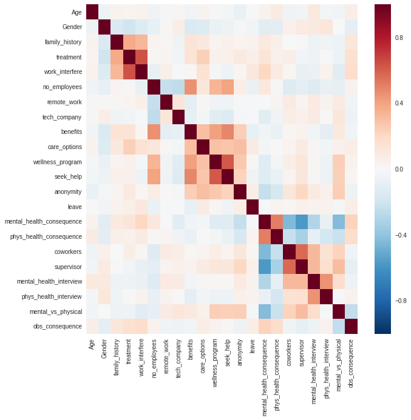

```python
plt.figure(figsize=(10, 10))

corr = numbersdf.corr()
sns.heatmap(corr,
            xticklabels=corr.columns.values,
            yticklabels=corr.columns.values)
plt.show()
```

Looking at the correlation matrix, we can see that there is a very strong, positive correlation between the treatment and work_interfere variables, so people who get treatment tend to have mental health issues that interfere with work and vice versa.

There is also a strong, positive correlation between the variables, wellness_program and seek_help. This means that people with companies that have employee wellness programs tend to have employers that offer resources on how to seek help and vice versa.

There is also a strong, positive correlation between the mental_health_consequence and phys_health_consequence variables. This means that people that think there would be a consequence for discussing mental health with an employer also think the same for a physical problem and vice versa.

Also, there is a strong positive, correlation between the coworkers and supervisor variables. This means that people who would be willing to discuss mental health with their coworkers feel the same about their supervisor and vice versa.

There is also a strong, negative correlation between the variables, mental_health_consequence and supervisor. This means that if someone thinks that there will be consequences for talking about mental health with their employer then they will not be willing to talk to their supervisor about it and vice versa.

# Machine Learning

Machine learning is finding patterns in the data and using the patterns to make predictions. For more information on machine learning, take a look at: https://en.wikipedia.org/wiki/Machine_learning

There are many different machine learning algorithms. Here are the ones we will be using along with their respective documentations.

Logistic Regression: http://scikit-learn.org/stable/modules/generated/sklearn.linear_model.LogisticRegression.html

K-Nearest Neighbor: http://scikit-learn.org/stable/modules/generated/sklearn.neighbors.KNeighborsClassifier.html

Random Forest: http://scikit-learn.org/stable/modules/generated/sklearn.ensemble.RandomForestClassifier.html

Decision Tree Classifier:http://scikit-learn.org/stable/modules/generated/sklearn.tree.DecisionTreeClassifier.html

Gaussian NB: http://scikit-learn.org/stable/modules/generated/sklearn.naive_bayes.GaussianNB.html

Quadratic Discriminant Analysis: http://scikit-learn.org/stable/modules/generated/sklearn.discriminant_analysis.QuadraticDiscriminantAnalysis.html#sklearn.discriminant_analysis.QuadraticDiscriminantAnalysis

```python
from sklearn.model_selection import train_test_split
from sklearn.ensemble import RandomForestClassifier
from sklearn.neighbors import KNeighborsClassifier
from sklearn.linear_model import LogisticRegression
from sklearn.tree import DecisionTreeClassifier
from sklearn.naive_bayes import GaussianNB
from sklearn.discriminant_analysis import QuadraticDiscriminantAnalysis
from sklearn.metrics import accuracy_score

models = dict()
models["Logistic Regression:"] = LogisticRegression()
models["K-Nearest Neighbor:"] = KNeighborsClassifier(n_neighbors=10)
models["Random Forest:"] = RandomForestClassifier(n_estimators=10)
models["Decision Tree Classifier:"] = DecisionTreeClassifier(max_depth=10)
models["Gaussian NB:"] = GaussianNB()
models["Quadratic Discriminant Analysis:"] = QuadraticDiscriminantAnalysis()
```

We're going to use the data to predict whether or not someone will get treatment for mental health or not. In order to do that, we're going to need to separate the treatment data from the rest of it. After that, we'll split the data into a training set and a testing set. We use the teseting set to mfind the patterns and we use the testing set to check how accurate our predictions are. In this situation, 75% of our data will go to training and 25% of it will go to testing.

We'll make a dataframe of the machine learning model and it's accuracy score (a percentage of how accurate the model is).

```python
X = numbersdf.drop(['treatment'], axis=1)
y = numbersdf['treatment']
X_train, X_test, Y_train, Y_test = train_test_split(X, y, test_size=0.25, random_state=10)

ml_df = pd.DataFrame(columns=["Model", "Accuracy"])

def score(model):
    clf = model
    clf.fit(X_train, Y_train)
    return accuracy_score(Y_test, clf.predict(X_test))

i = 0
for name, model in models.items():
    accuracy = score(model)
    ml_df.set_value(i, "Model", name)
    ml_df.set_value(i, "Accuracy", accuracy*100)
    i += 1

ml_df
```

|  | Model | Accuracy |
| --- | --- | --- |
| 0 | Logistic Regression: | 50.1587 |
| 1 | K-Nearest Neighbor: | 74.6032 |
| 2 | Random Forest: | 77.7778 |
| 3 | Decision Tree Classifier: | 70.1587 |
| 4 | Gaussian NB: | 50.1587 |
| 5 | Quadratic Discriminant Analysis: | 49.8413 |

We can make a bar graph out of this dataframe to visualize the accurcies of the machine learning models and see which one is the most accurate.

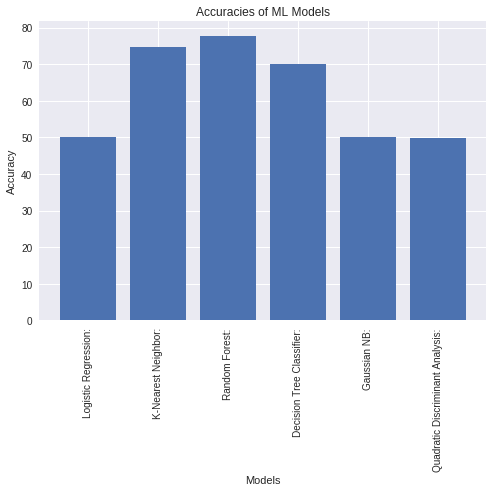

```python
plt.bar(range(len(ml_df['Model'])), ml_df['Accuracy'], align='center')
plt.xticks(range(len(ml_df['Model'])), ml_df['Model'], rotation='vertical')
plt.xlabel("Models")
plt.ylabel("Accuracy")
plt.title('Accuracies of ML Models')

plt.show()
```

Looking at our bar graph, we can see that Random Forest is the most accurate of our models for the data.

# Conclusion

Mental health is important and although people should be able to get treatment regardless of what company they work for, this is not the case. Clearly there are a lot of different factors that come into play that determine whether or not people get treatment for mental health. It is important that people who need treatment get it so that they won't have to deal with mental illness. Hopefully, this data analysis, visualization, and machine learning will be useful for people that may need mental health treatment. They can look at this when when making a decision to join a tech company and can use our machine learning model to see if they will be able to get treatment or not.